# Quiz 4

Amanda Luken

2/20/2020

## Merge the data

First we will clean up the expenditure data by removing the non-data lines and adding cleaner column headings. Afterwards, we remove the rows for all of the US and DC with the filter function. Then, we can tidy up the data with gather to transform the horizontal data to vertical. Afterwards, we group by location to calculate the average spending for each state across all years.

For the federal regions dataset, we can get rid of the first row to make the data appear as two columns, and then add new heading names.

Afterwards, we are ready to merge the datasets by using the join function. Location is the common variable across datasets, so this will be the connecting key. The line underneath the join is to enumerate the levels of the Region variable, so that the barplot plots them in order.

```r
library(tidyverse); library(dplyr); library(ggplot2)
dat <- read.csv("/cloud/project/quiz-4-aluken95/healthcare-spending.csv", sep = ",", header =TRUE) #manually remove the first two rows and the notes at the bottom from the file
colnames(dat) <- c("Location", 1991:2014)
dat <- dat %>%
  filter(Location != "United States") %>%
  filter(Location != "District of Columbia") %>%
  gather(Year, TotHealthSpend, -Location) %>%
  group_by(Location) %>%
  summarize(averageSpend=mean(TotHealthSpend))

fR <- read.delim("/cloud/project/quiz-4-aluken95/federalRegions.txt", header = FALSE)
fR <- fR[2:nrow(fR),]
colnames(fR) <- c("Region", "Location")

combined <- left_join(fR, dat, by = "Location")
combined$Region <- factor(combined$Region, levels = c(1, 2, 3 ,4 , 5, 6, 7, 8, 9, 10))
```

## Stacked Barplots

Now, we are ready to plot the bar graph. We use the fill by location to discriminate sections of the stack. I provide axis and title labels, along with labels on the stacks to specify which state they belong to.

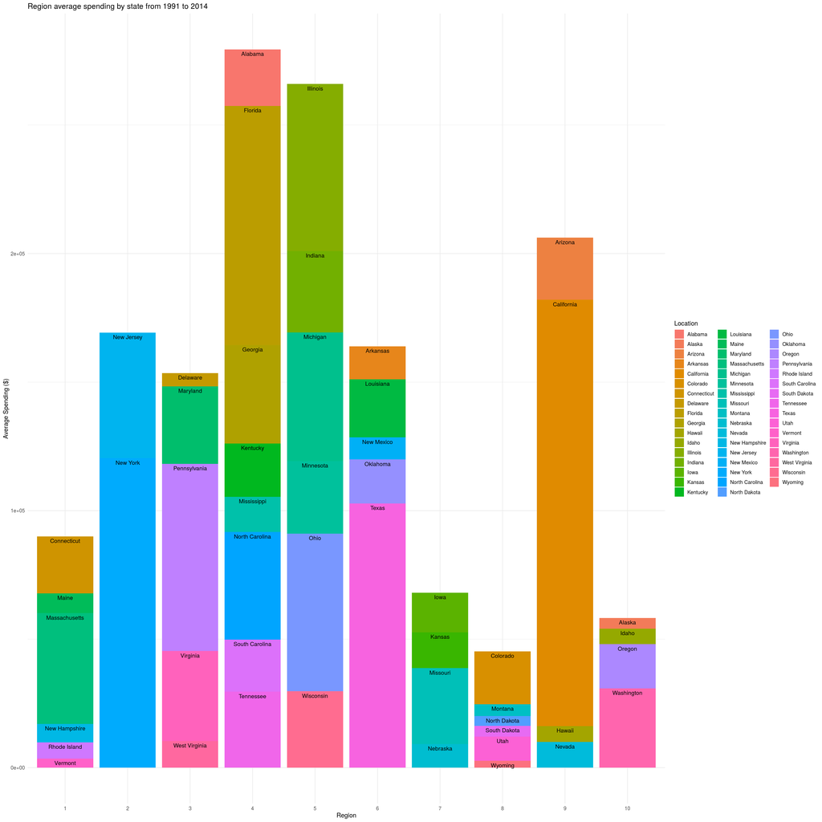

```r
p <- ggplot(combined, aes(x=factor(Region), y=averageSpend, fill = Location)) +
  geom_bar(stat="identity", position="stack") +
  theme_minimal() +
  labs(title = "Region average spending by state from 1991 to 2014", y = "Average Spending ($)", x= "Region") +
  geom_text(aes(label=Location), vjust=1.6, color = "black", position = "stack", size = 3.5)

p
```